# STAT 240

Week 12: HTML

Owen G. Ward

## Today

- Quick Review of Last Week
  - Only the EM stuff, the example not important
- Extracting Data from HTML
- Review for Coding Exam

## Logistics

- Coding Exam next Friday
- Written Exam April 14th
  - Practice problems for this already on canvas
  - All of class next week will be review for this

# Review: Likelihood and Mixture Models

## Likelihood

- The likelihood is the “probability” of the data given the parameter
- It is a function of the parameter, $\mathcal{L}(\theta|x)$
- Maximum Likelihood Estimation finds the value of $\theta$ which maximises this function $\mathcal{L}(\theta|x)$
  - This will be the same value of $\theta$ which maximises $\log\mathcal{L}(\theta|x)$

## Likelihood functions

- Suppose we flip a coin several times, $P(Heads) = \theta$
- Get $n_H$ heads and $n_T$ tails, likelihood given by

$$\mathcal{L}(\theta|x) = \theta^{n_H}(1-\theta)^{n_T}$$

- This is the product of likelihood for each individual coin flip, because independent
- The log-likelihood is

$$\log\mathcal{L}(\theta|x) = n_{H}\log\theta + n_{T}\log(1-\theta)$$

## Maximum Likelihood

- Find the value of $\theta$ which maximises either of these functions
- Can do this using calculus for this problem, others harder
  - No unique solution in many problems
- Can also use `optim` for problems like this, may not work in harder problems

## Mixture Models

- Let’s see even simpler example than last week
- Let’s suppose we have two normal distributions, $\mathcal{N}(0, 1)$ and $\mathcal{N}(-5, 2)$
- For each data point $X_i$ we flip a coin with $P(Heads) = \theta$
  - If the coin is heads then $X_i\sim\mathcal{N}(0, \sigma = 1)$
  - If the coin is tails then $X_i\sim\mathcal{N}(-5, \sigma = 2)$
- We only observe $X_i$, not each coin flip

## Simulating Data for this Model

```r
set.seed(240)
theta <- 0.7
x <- rep(NA, 100)
coins <- sample(1:2, size = 100, replace = TRUE, prob = c(theta, 1 - theta))
coins[1:10]
```

```
 [1] 1 2 1 1 1 1 1 1 1 1
```

```r
for(i in 1:length(coins)) {
  if(coins[i] == 1) {
    x[i] <- rnorm(1, mean = 0, sd = 1)
  }
  if(coins[i] == 2) {
    x[i] <- rnorm(1, mean = -5, sd = 2)
  }
}
```

## The Data

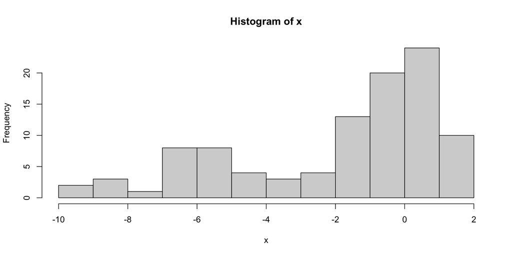

```r
hist(x)
```

## Exercise

- Simulate some new data where we make the $\sigma$ for both normal distributions smaller. What happens to the histogram?

## Solution

## Fitting a Mixture Model

- The likelihood for this model is (with simplifications)
  $$\mathcal{L}(\theta|x) = \theta \mathcal{N}(0, 1) +
  (1-\theta)\mathcal{N}(-5, 2)$$
- We cannot find the Maximum Likelihood for this model if we didn’t know the true Normal distributions

## EM Algorithm

```r
library(EMCluster)
restarts <- 100
models <- vector("list", restarts)
lls <- rep(NA, restarts)
for (i in 1:restarts) {
  models[[i]] <- emcluster(as.matrix(x),
                           simple.init(as.matrix(x), nclass = 2))
  lls[i] <- models[[i]]$llhdval
}
model <- models[[which.max(lls)]]
```

## The Result

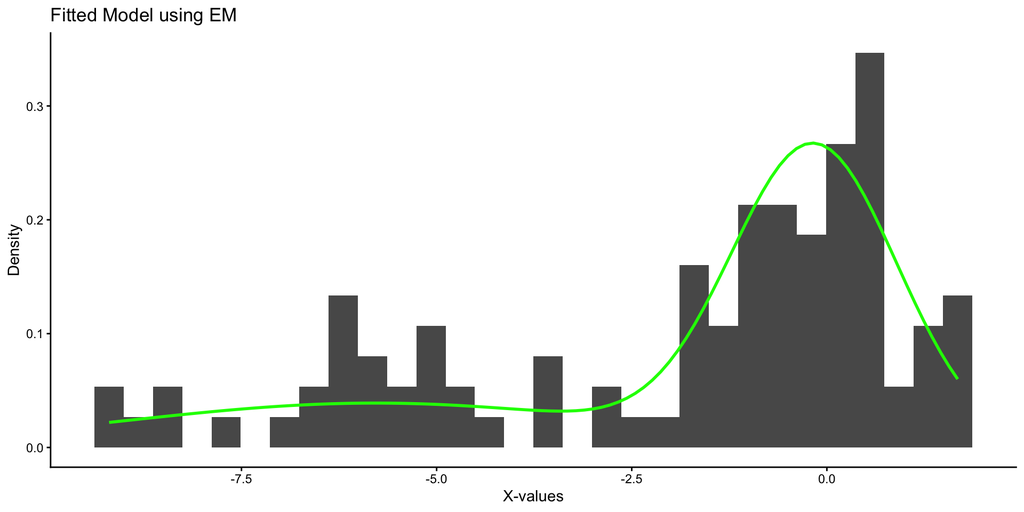

## More Details on Mixture Models

- This mixture model doesn’t classify each point into a cluster, it gives us the probability each data point is in each of the components

```r
model$pi
```

```
[1] 0.3119936 0.6880064
```

- So somewhat different to k-means, but useful
- Common in other more advanced Machine Learning methods

# HTML

# HTML Basics

- HTML is Hypertext markup language
- Best online reference: https://www.w3schools.com

## HTML: Links

```html
<a href="http://www.example.com">A link</a>
```

[A link](http://www.example.com)

## HTML: Full page

```html
<!DOCTYPE html>
<html>
<head>
<title>Page Title</title>
</head>
<body>

<h1>This is a Heading</h1>
<p>This is a paragraph.</p>

</body>
</html>
```

# This is a Heading

This is a paragraph.

## HTML: Structure

An HTML element is a start tag, (optionally) content, and then (optionally) an end tag

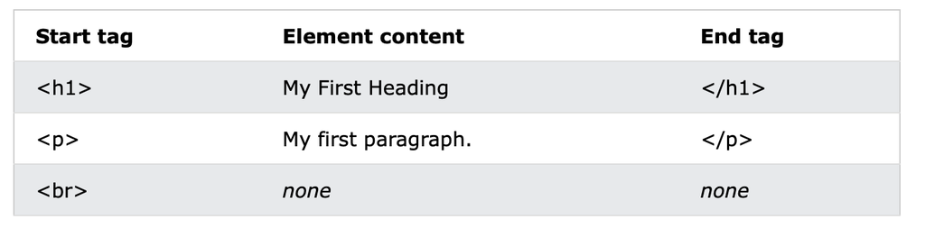

## HTML: Structure

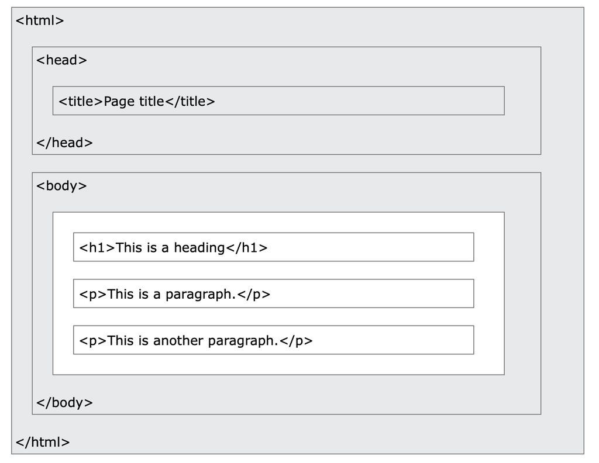

## HTML: Headings

```html
<h1>This is heading 1</h1>
<h2>This is heading 2</h2>
<h3>This is heading 3</h3>
```

# This is heading 1

## This is heading 2

### This is heading 3

## HTML: Learning

Ways to learn HTML:

- Modify an existing page
- Read tutorials on https://www.w3schools.com
- Use another markdown language (like qmd) that compiles to html, and study the result of the compilation
- Use dreamweaver or another professional piece of design software, inject your own html into aspects that aren’t static designs

## HTML: URLs

- Going back to the link, a URL is a “Uniform Resource Locators”
- Example: http://example.com Here the protocol is http (hyper text transport protocol) and the server is example.com
- Other examples of protocols: git, https, sftp

## HTML: URLs

- A URL can also indicate a file on the server: http://example.com/path/filename
- Here “path/filename” can indicate a file on the server
- But, it doesn’t have to:

http://example.com/API?action=start-motor

- Here there isn’t (necessarily) a file on the server with the name “API?action=start-motor”. Instead, the question mark is indicating that parameters will be “passed” to a “program” called “API”

## HTML: URLs

- Usernames and passwords can be embedded in URLs: https://user:pa55w0rd@www.example.com/path/filename
- The destination “port” can also be indicated: https://user:pa55w0rd@www.example.com:8080/path/filename
- The server listed in a URL can be specified in unicode through a special mapping from unicode to ASCII specified by the “Internationalized Resource Identifier” (IRI) standard.
- Example: http://例子.卷筒纸 and http://xn–fsqu00a.xn–3lr804guic/ are the same URL

# The End

- Of new material
- Everything for the rest of today and next week will be review for the exams
- Please ask questions

# Coding Exam Review

## Key Ideas

- All material examinable, majority will be on the second half of the semester
- May be some concepts from before midterm
- Shorter than the practice exam (3 questions)

## Preparing

- Do the practice exam, the format will be very similar
  - Download a dataset
  - Solve some short problems
  - Write functions, implement methods we have covered
  - Create and submit your pdf file

## Submitting to Crowdmark

- Make sure you are comfortable with rendering your document!
- Do not display large data output, you will be penalised!
  - This is written in the instructions this time
- If you are asked to show a number, it must be in your pdf file for you to get points

## Dealing with Errors

- You must submit a pdf, otherwise you will get 0
- We have covered how to deal with errors before
- Use `#| eval: false` in individual code chunks
  - Needs to be at the very start of chunk, spacing important
- Tip: Have a code chunk at the bottom of your template file with this, can copy and paste if needed

## If all your code doesn’t run

- Modify the YAML at the very top to not run any of your code

```r
knitr:
  opts_chunk:
    eval: false
```

## R Packages

- Will need to use packages, make sure to load them
- Any packages we saw in the class could be required
  - `tidyverse`
  - `stringr`
  - `caret`
  - `class`
  - `RSql`
  - `DBI`
  - etc.

## Review of Key Topics

- Will spend the rest of the class reviewing each topic covered, types of questions you could get
- Make sure you can do all the labs, the midterm, you will be well prepared

## Basic Programming

- Reading data into R
- Modifying data, accessing rows/columns, etc
- Basic plots of data
- Basic statistical functions (`mean, median, max`, etc)

## Functions and Lists

- Be able to write simple functions in R
- Lists and how to access elements in lists

## SQL and Databases

- Create and access databases with `RSQLite`
- Adding datasets, inserting rows
- Querying data from a database
  - `SELECT`, `FROM`, `WHERE`, `ORDER`, `AS`, `GROUP BY`, `LIKE`

## Regression

- Fitting linear regression using `lm`
- Extract the $\hat{\alpha},\hat{\beta}$ from the fitted model
- Basic use of `optim` for small problems (computing SSE)

## APIs

- Understand how they work, be familiar with the ones we used in class

## KNN and Prediction

- Split data into a training and test set
- Fit to training, predict on test
- Compute RMSPE
- Do this for linear regression and KNN

## Classification and Cross Validation

- How to modify KNN to perform classification
  - Different function in different package
  - Compute accuracy instead of RMSPE
- Choose the value of K using cross-validation
  - How to perform this for new data

## Clustering

- Implement k-means clustering and display output
- Know the key ideas in the algorithm
- How to modify the stopping criteria, change the number of random starts

## Strings

- Will probably want to use `stringr`
- Will only use string functions, ideas covered in the slides

## Likelihood and Mixture Models

- Be able to write an R function to compute the likelihood or log-likelihood
- Be able to plot the result for a range of values of the parameter
- Implement the EM algorithm (for very simple problem)